# Tidy Tuesday 06-07-2022: Pride Corporate Accountability Project

2022-06-07

## The Data

This week’s data comes from [Data for Progress](https://www.dataforprogress.org/accountable-allies). The data details pride sponsors, such as Fortune 500 companies, that simultaneously donate to pride events and anti-LGTQ+ politicians. A major focus of Data for Progress’s mission is to hold these corporations accountable for their actions.

```r
pride_aggregates <- readr::read_csv('https://raw.githubusercontent.com/rfordatascience/tidytuesday/master/data/2022/2022-06-07/pride_aggregates.csv')
fortune_aggregates <- readr::read_csv('https://raw.githubusercontent.com/rfordatascience/tidytuesday/master/data/2022/2022-06-07/fortune_aggregates.csv')
static_list <- readr::read_csv('https://raw.githubusercontent.com/rfordatascience/tidytuesday/master/data/2022/2022-06-07/static_list.csv')
pride_sponsors <- readr::read_csv('https://raw.githubusercontent.com/rfordatascience/tidytuesday/master/data/2022/2022-06-07/pride_sponsors.csv')
corp_by_politicians <-readr::read_csv('https://raw.githubusercontent.com/rfordatascience/tidytuesday/master/data/2022/2022-06-07/corp_by_politician.csv')
donors <- readr::read_csv('https://raw.githubusercontent.com/rfordatascience/tidytuesday/master/data/2022/2022-06-07/donors.csv')
```

## Creating a Tree Map

I wanted to make a tree map for this week’s Tidy Tuesday where the area a pride-sponsor Fortune 500 company takes up in the the plot is proportional to their donations to anti-LGTQ+ politicians. In order to keep the plot readable, I only included the 20 pride-sponsor Fortune 500 companies that donated the most to anti-LGTQ+ politicians. Much of the data wrangling done in the code blocks below were largely stylistic – done to make the Tree Map prettier.

```r
top_20_new <- fortune_aggregates %>%
  rename(Total.Contributed = `Total Contributed`)%>%
  filter(Company != "Grand Total") %>%
  arrange(desc(Total.Contributed)) %>%
  slice(1:20) %>%
  mutate(Total.Contributed = round(Total.Contributed, digits = 0)) %>%
  mutate(options(scipen = 999)) %>%
  mutate(Company = case_when(Company == "Enterprise Products Partners" ~ "Enterprise Products",
                             Company == "American Electric Power" ~ "American \nElectric",
                             Company == "UnitedHealth Group" ~ "UnitedHealth",
                             Company == "Molina Healthcare" ~ "Molina \nHealthcare",
                             Company == "Berkshire Hathaway" ~ "Berkshire \nHathaway",
                             TRUE ~ Company))
```

## The Plot

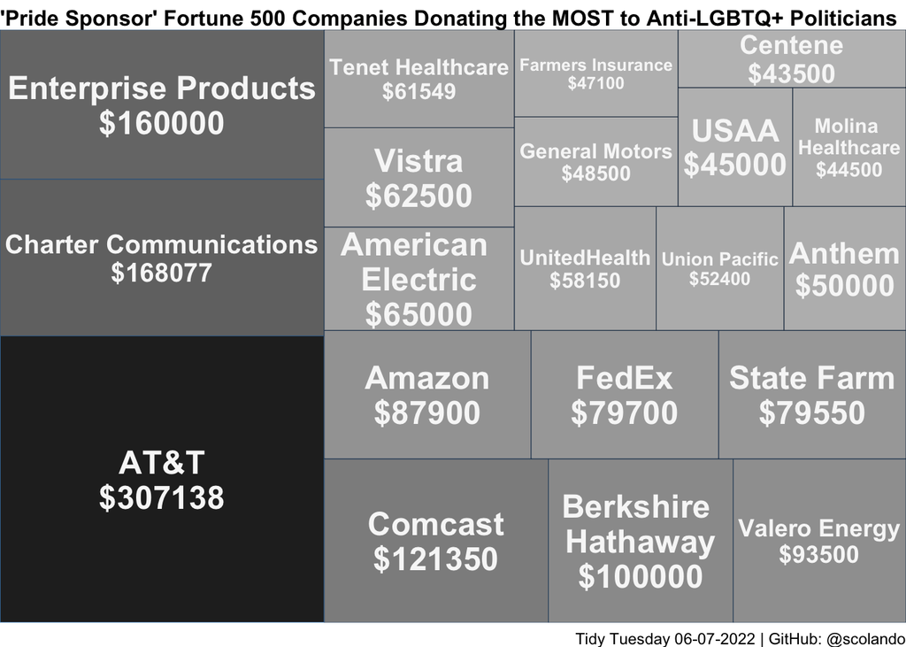

```r
ggplot(top_20_new, aes(area = Total.Contributed, fill = Total.Contributed, label = paste(Company, paste("$",Total.Contributed, sep = ""), sep = "\n"), color = Total.Contributed)) +
  geom_treemap()+
  geom_treemap_text(color = "gray97", min.size = 0, fontface = "bold", place = "center")+
  theme_void()+
  theme(legend.position="none") +
  theme(plot.title = element_text(size = 12, face = "bold"))+
  scale_fill_gradient(low = "gray75", high = "gray15", space = "Lab")+
  ggtitle("'Pride Sponsor' Fortune 500 Companies Donating the MOST to Anti-LGBTQ+ Politicians")+
  labs(caption = "Tidy Tuesday 06-07-2022 | GitHub: @scolando")
```

## A Subset of Non-Two-Faced Companies – supporting NYC Pride!

I included a short list of 20 randomly sampled pride sponsors for NYC pride that did not donate to anti_LGBTQ+ politicians. There are 125 such sponsors. Feel free to run the R-code chunk to see more of these pride sponsors.

```r
yay_nottwofaced_companies <- subset(pride_sponsors, !(Company %in% pride_aggregates$Company)) %>%
  select(Company, 'Pride Event Sponsored') %>%
  rename(Pride_Event = 'Pride Event Sponsored') %>%
  filter(Pride_Event == "NYC Pride") %>%
  select(Company)


sample_n(yay_nottwofaced_companies, 20)
```

```
## # A tibble: 20 × 1
##    Company
##    <chr>
##  1 Chase
##  2 PVH
##  3 sage Advocacy & services for LGBT Elders
##  4 SKYY Vodka
##  5 TD Bank
##  6 Nexus Radio
##  7 Oscar Wilde Tours
##  8 Geeks Out
##  9 Deutsche Bank
## 10 NBA
## 11 National Pulse Memorial & Museum
## 12 NY Botanical Garden
## 13 Immigration Equality
## 14 New York Life
## 15 The Cathedral Church of Saint John the Divine
## 16 CeraVe
## 17 Diet Coke
## 18 IGLTA
## 19 The Ali Forney Center
## 20 smithsonian
```